# **Le marché des véhicules électriques**

### **Question 4** : Popularité de la marque et du modèle

Identifiez les marques et les modèles les plus populaires parmi les véhicules électriques enregistrés.

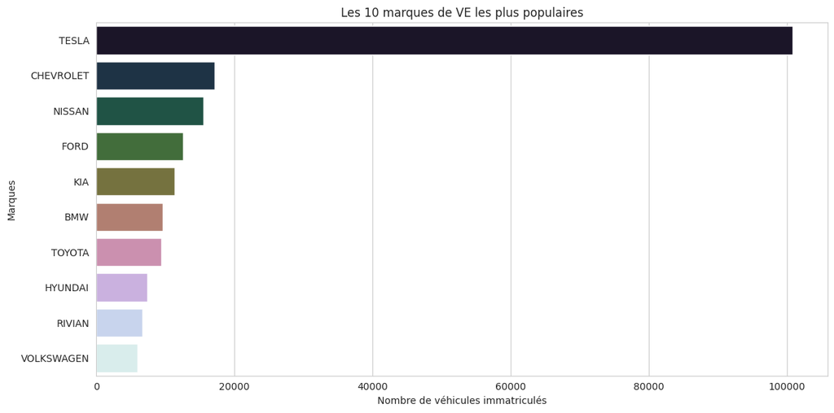

Le graphique ci-dessus montre que :

- TESLA est en tête avec le plus grand nombre de véhicules immatriculés.
- CHEVROLET est le deuxième constructeur le plus populaire, suivi de NISSAN, bien que les deux aient nettement moins d’immatriculations que TESLA.
- FORD, KIA, BMW, TOYOTA, HYUNDAI, RIVIAN et VOLKSWAGEN suivent par ordre décroissant du nombre de véhicules immatriculés.

### **Question 5** : Les modèles les plus populaires

Examinons les modèles les plus populaires de ces principaux fabricants pour mieux comprendre les préférences des consommateurs au niveau du modèle

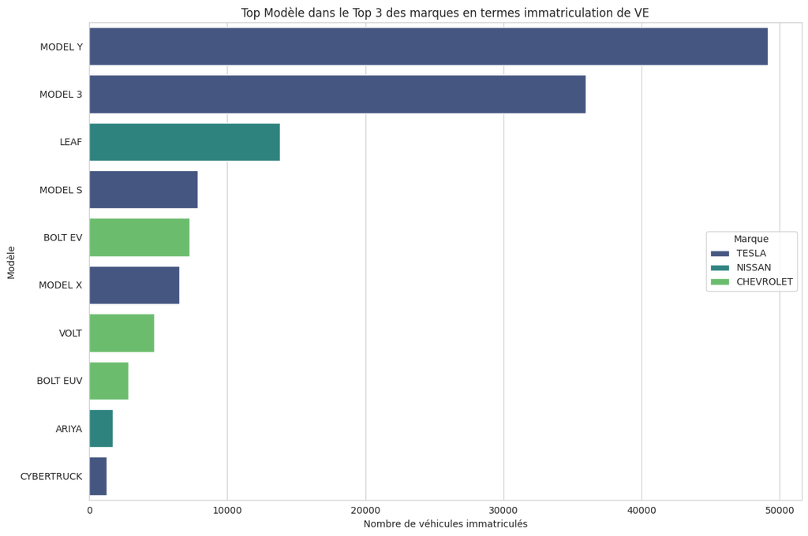

Le graphique ci-dessus montre la répartition des immatriculations de véhicules électriques entre les différents modèles des trois principaux constructeurs : TESLA, NISSAN et CHEVROLET.

L’autonomie électrique indique la distance qu’un véhicule électrique peut parcourir avec une seule charge, et les progrès de la technologie des batteries n’ont cessé d’augmenter ces autonomies au fil des ans. Examinons donc `la distribution des autonomies électriques` dans l’ensemble de données et identifions `les tendances notables`, telles que `les améliorations au fil du temps` ou `les variations entre différents types de véhicules ou fabricants`.